# STAT 545A Homework 3

Junbin ZHANG

Sept 25, 2018

# Bring rectangular data in

```r
## load gapminder
suppressPackageStartupMessages(library(gapminder))
## load tidyverse
suppressPackageStartupMessages(library(tidyverse))
```

# Tasks

## Task #1

**Get the maximum and minimum of GDP per capita for all continents.**

We first create a table to show the maximum and minimum of GDP per capita for all continents.

```r
# get data of maximum and minimum of GDP per capita for all continents
data <- gapminder %>%
  # group by continent
  group_by(continent) %>%
  # calculate summaries
  summarize(
    max_gdpPercap = max(gdpPercap),
    min_gdpPercap = min(gdpPercap),
  )
# get corresponding rows for the maximum data
max_country <- gapminder %>%
  # filter data with maximum GDP per capita
  filter(gdpPercap %in% data$max_gdpPercap) %>%
  # create column with country and year
  mutate(
    max_country_year = paste(country, year, sep=",")
  ) %>%
  # make sure the order is the same as "data"
  arrange(continent) %>%
  # select only mutated column
  select(max_country_year)

# get corresponding rows for the minimum data
min_country <- gapminder %>%
  # filter data with minimum GDP per capita
  filter(gdpPercap %in% data$min_gdpPercap) %>%
  # create column with country and year
  mutate(
    min_country_year = paste(country, year, sep=",")
  ) %>%
  # make sure the order is the same as "data"
  arrange(continent) %>%
  # select only mutated column
  select(min_country_year)

# display table with combined data
data.frame(
  continent = data$continent,
  max_gdpPercap = data$max_gdpPercap,
  max_country,
  min_gdpPercap = data$min_gdpPercap,
  min_country
) %>%
  knitr::kable()
```

| continent | max_gdpPercap | max_country_year | min_gdpPercap | min_country_year |
| --- | --- | --- | --- | --- |
| Africa | 21951.21 | Libya,1977 | 241.1659 | Congo, Dem. Rep.,2002 |
| Americas | 42951.65 | United States,2007 | 1201.6372 | Haiti,2007 |
| Asia | 113523.13 | Kuwait,1957 | 331.0000 | Myanmar,1952 |
| Europe | 49357.19 | Norway,2007 | 973.5332 | Bosnia and Herzegovina,1952 |
| Oceania | 34435.37 | Australia,2007 | 10039.5956 | Australia,1952 |

Let’s show them on a scatterplot.

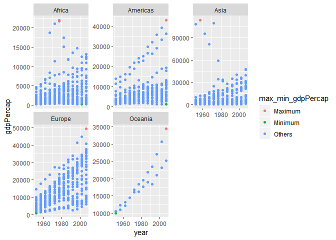

```r
gapminder %>%
  # create a new column to indicate whether a data point is maximum or minimum gdpPercap
  mutate(
    max_min_gdpPercap = ifelse(
      gdpPercap %in% data$max_gdpPercap,
      "Maximum",
      ifelse(
        gdpPercap %in% data$min_gdpPercap,
        "Minimum",
        "Others"
        )
      )
  ) %>%
  # year as x axis and gdpPercap as y axis, use max_min_gdpPercap as color
  ggplot(aes(year, gdpPercap, color = max_min_gdpPercap), alpha = 0.1) +
  # make it a scatterplot
  geom_point() +
  # facetting using continent
  facet_wrap(~continent, scales = "free_y") +
  # make a better x axis
  scale_x_continuous(breaks = scales::pretty_breaks(n = 3))
```

From the table and figure, we notice the maximum and minimum values of gdpPercap are different in different continents. They also appear in different countries and years. The scatterplot provides a better view, except we cannot get which countries has the maximum/minimum gdpPercap.

## Task #2

**Look at the spread of GDP per capita within the continents.**

Let’s show a table with the range, mean and deviation of GDP per capita within the continents.

```r
gapminder %>%
  # group by continent
  group_by(continent) %>%
  # calculate summaries
  summarize(
    # calculate minimum
    min_gdpPercap = min(gdpPercap),
    # calculate maximum
    max_gdpPercap = min(gdpPercap),
    # calculate mean
    mean_gdpPercap = mean(gdpPercap),
    # calculate standard deviation
    sd_gdpPercap = sd(gdpPercap)
  ) %>%
  # display the table
  knitr::kable()
```

[output not shown]

We can use histogram and boxplot to do the same task. Notice that in histogram, `scales="free"` is needed to scale both x and y axes, so the figure should be clearer.

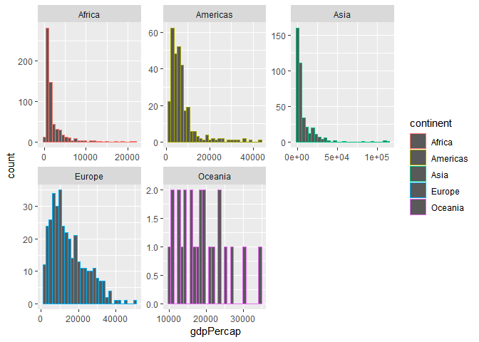

```r
gapminder %>%
  # gdpPercap as x axis
  ggplot(aes(gdpPercap, color = continent)) +
  # facetting by continent
  facet_wrap(~continent, scales = "free") +
  # make it a histogram
  geom_histogram(bins = 30)  +
  # make a better x axis
  scale_x_continuous(breaks = scales::pretty_breaks(n = 3))
```

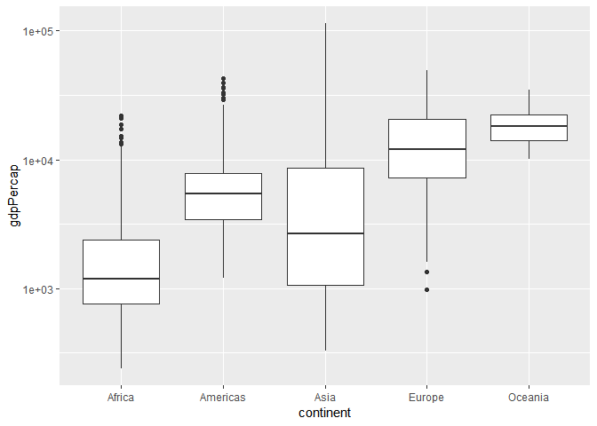

```r
gapminder %>%
  # continent as x axis, gdpPercap as y axis
  ggplot(aes(continent, gdpPercap)) +
  # scale y axis by log10
  scale_y_log10() +
  # make it a boxplot
  geom_boxplot()
```

## Task #3

**Compute a trimmed mean of life expectancy for different years. Or a weighted mean, weighting by population. Just try something other than the plain vanilla mean.**

Let’s calculate the weighted mean of life expectancy, weighting by population.

```r
means <- gapminder %>%
  # group by year
  group_by(year) %>%
  # calculate vanilla mean and weighted mean
  summarize(
    vanilla_mean_lifeExp = mean(lifeExp),
    weighted_mean_lifeExp_by_pop = weighted.mean(lifeExp, pop)
  )

# display as table
means %>%
  knitr::kable()
```

| year | vanilla_mean_lifeExp | weighted_mean_lifeExp_by_pop |
| --- | --- | --- |
| 1952 | 49.05762 | 48.94424 |
| 1957 | 51.50740 | 52.12189 |
| 1962 | 53.60925 | 52.32438 |
| 1967 | 55.67829 | 56.98431 |
| 1972 | 57.64739 | 59.51478 |
| 1977 | 59.57016 | 61.23726 |
| 1982 | 61.53320 | 62.88176 |
| 1987 | 63.21261 | 64.41635 |
| 1992 | 64.16034 | 65.64590 |
| 1997 | 65.01468 | 66.84934 |
| 2002 | 65.69492 | 67.83904 |
| 2007 | 67.00742 | 68.91909 |

Let’s draw some line plots to show them.

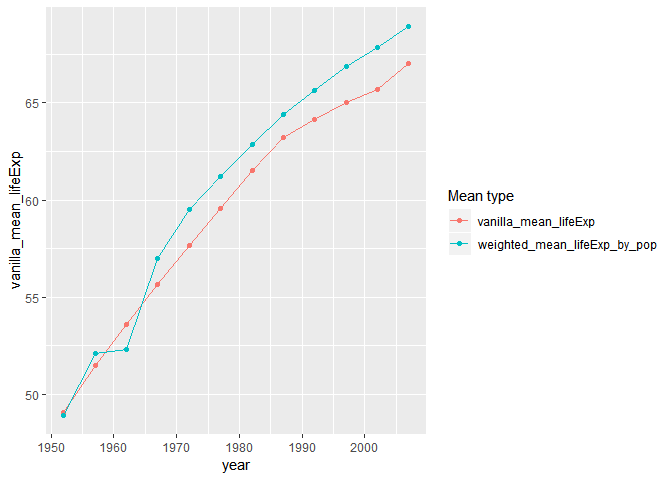

```r
means %>%
  ggplot() +
  # make a line plot with points for vanilla_mean_lifeExp
  geom_line(aes(year, vanilla_mean_lifeExp, color = "vanilla_mean_lifeExp")) +
  geom_point(aes(year, vanilla_mean_lifeExp, color = "vanilla_mean_lifeExp")) +
  # make a line plot with points for weighted_mean_lifeExp_by_pop
  geom_line(aes(year, weighted_mean_lifeExp_by_pop, color = "weighted_mean_lifeExp_by_pop")) +
  geom_point(aes(year, weighted_mean_lifeExp_by_pop, color = "weighted_mean_lifeExp_by_pop")) +
  # add legend for two lines
  scale_color_discrete("Mean type")
```

Basically, the life expectancy tends to increase thoughout the years.

## Task #4

**How is life expectancy changing over time on different continents?**

Let’s first use a table to show the trend of how life expectancy changes. We also calculate the changes in every five years.

```r
changes <- gapminder %>%
  # need to group by continent and year
  group_by(continent, year) %>%
  # use mean as benchmark
  summarize(
    mean_lifeExp = mean(lifeExp)
  ) %>%
  # calculate absolute change and relative change
  mutate(
    change_in_five_years = mean_lifeExp - lag(mean_lifeExp),
    accumulate_change = mean_lifeExp- first(mean_lifeExp)
  )

# display the table
changes %>%
  knitr::kable()
```

| continent | year | mean_lifeExp | change_in_five_years | accumulate_change |
| --- | --- | --- | --- | --- |
| Africa | 1952 | 39.13550 | NA | 0.000000 |
| Africa | 1957 | 41.26635 | 2.1308462 | 2.130846 |
| Africa | 1962 | 43.31944 | 2.0530962 | 4.183942 |
| Africa | 1967 | 45.33454 | 2.0150962 | 6.199039 |
| Africa | 1972 | 47.45094 | 2.1164038 | 8.315442 |
| Africa | 1977 | 49.58042 | 2.1294808 | 10.444923 |
| Africa | 1982 | 51.59287 | 2.0124423 | 12.457365 |
| Africa | 1987 | 53.34479 | 1.7519231 | 14.209288 |
| Africa | 1992 | 53.62958 | 0.2847885 | 14.494077 |
| Africa | 1997 | 53.59827 | -0.0313077 | 14.462769 |
| Africa | 2002 | 53.32523 | -0.2730385 | 14.189731 |
| Africa | 2007 | 54.80604 | 1.4808077 | 15.670538 |
| Americas | 1952 | 53.27984 | NA | 0.000000 |
| Americas | 1957 | 55.96028 | 2.6804400 | 2.680440 |
| Americas | 1962 | 58.39876 | 2.4384800 | 5.118920 |
| Americas | 1967 | 60.41092 | 2.0121600 | 7.131080 |
| Americas | 1972 | 62.39492 | 1.9840000 | 9.115080 |
| Americas | 1977 | 64.39156 | 1.9966400 | 11.111720 |
| Americas | 1982 | 66.22884 | 1.8372800 | 12.949000 |
| Americas | 1987 | 68.09072 | 1.8618800 | 14.810880 |
| Americas | 1992 | 69.56836 | 1.4776400 | 16.288520 |
| Americas | 1997 | 71.15048 | 1.5821200 | 17.870640 |
| Americas | 2002 | 72.42204 | 1.2715600 | 19.142200 |
| Americas | 2007 | 73.60812 | 1.1860800 | 20.328280 |
| Asia | 1952 | 46.31439 | NA | 0.000000 |
| Asia | 1957 | 49.31854 | 3.0041503 | 3.004150 |
| Asia | 1962 | 51.56322 | 2.2446788 | 5.248829 |
| Asia | 1967 | 54.66364 | 3.1004170 | 8.349246 |
| Asia | 1972 | 57.31927 | 2.6556291 | 11.004875 |
| Asia | 1977 | 59.61056 | 2.2912873 | 13.296162 |
| Asia | 1982 | 62.61794 | 3.0073830 | 16.303545 |
| Asia | 1987 | 64.85118 | 2.2332424 | 18.536788 |
| Asia | 1992 | 66.53721 | 1.6860303 | 20.222818 |
| Asia | 1997 | 68.02052 | 1.4833030 | 21.706121 |
| Asia | 2002 | 69.23388 | 1.2133636 | 22.919485 |
| Asia | 2007 | 70.72848 | 1.4946061 | 24.414091 |
| Europe | 1952 | 64.40850 | NA | 0.000000 |
| Europe | 1957 | 66.70307 | 2.2945667 | 2.294567 |
| Europe | 1962 | 68.53923 | 1.8361667 | 4.130733 |
| Europe | 1967 | 69.73760 | 1.1983667 | 5.329100 |
| Europe | 1972 | 70.77503 | 1.0374333 | 6.366533 |
| Europe | 1977 | 71.93777 | 1.1627333 | 7.529267 |
| Europe | 1982 | 72.80640 | 0.8686333 | 8.397900 |
| Europe | 1987 | 73.64217 | 0.8357667 | 9.233667 |
| Europe | 1992 | 74.44010 | 0.7979333 | 10.031600 |
| Europe | 1997 | 75.50517 | 1.0650667 | 11.096667 |
| Europe | 2002 | 76.70060 | 1.1954333 | 12.292100 |
| Europe | 2007 | 77.64860 | 0.9480000 | 13.240100 |
| Oceania | 1952 | 69.25500 | NA | 0.000000 |
| Oceania | 1957 | 70.29500 | 1.0400000 | 1.040000 |
| Oceania | 1962 | 71.08500 | 0.7900000 | 1.830000 |
| Oceania | 1967 | 71.31000 | 0.2250000 | 2.055000 |
| Oceania | 1972 | 71.91000 | 0.6000000 | 2.655000 |
| Oceania | 1977 | 72.85500 | 0.9450000 | 3.600000 |
| Oceania | 1982 | 74.29000 | 1.4350000 | 5.035000 |
| Oceania | 1987 | 75.32000 | 1.0300000 | 6.065000 |
| Oceania | 1992 | 76.94500 | 1.6250000 | 7.690000 |
| Oceania | 1997 | 78.19000 | 1.2450000 | 8.935000 |
| Oceania | 2002 | 79.74000 | 1.5500000 | 10.485000 |
| Oceania | 2007 | 80.71950 | 0.9795000 | 11.464500 |

Let’s plot it out.

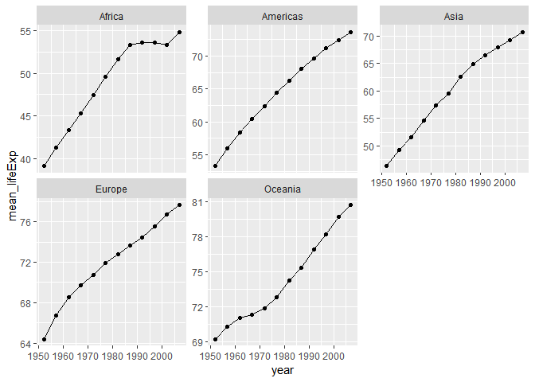

```r
changes %>%
  # year as x axis and mean_lifeExp as y axis
  ggplot(aes(year, mean_lifeExp)) +
  # facetting by continent
  facet_wrap(~continent, scales="free_y")+
  # make a line plot with points
  geom_line() +
  geom_point()
```

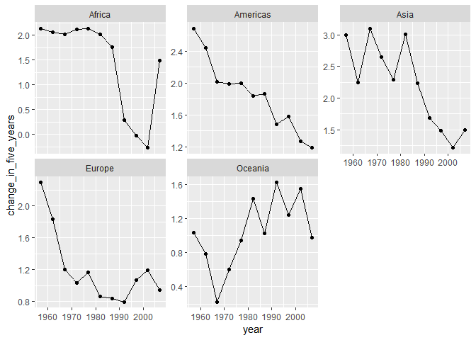

```r
changes %>%
  # remove NA values
  filter(!is.na(change_in_five_years)) %>%
  # year as x axis and change_in_five_years as y axis
  ggplot(aes(year, change_in_five_years)) +
  # facetting by continent
  facet_wrap(~continent, scales = "free_y")+
  # make a line plot with points
  geom_line() +
  geom_point()
```

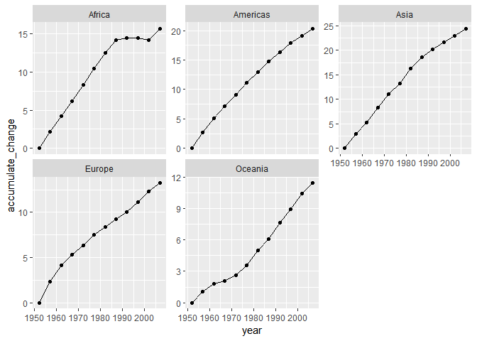

```r
changes %>%
  # year as x axis and accumulate_change as y axis
  ggplot(aes(year, accumulate_change)) +
  # facetting by continent
  facet_wrap(~continent, scales = "free_y")+
  # make a line plot with points
  geom_line() +
  geom_point()
```

From the above two figures, we get to know:

- Except Africa suffered from a decrement between 1997 and 2002, all the continents have increment throughout the years.
- Generally speaking, except Oceania, the speeds of lifeExp grows of other continents become smaller and smaller.

## Task #5

**Report the absolute and/or relative abundance of countries with low life expectancy over time by continent: Compute some measure of worldwide life expectancy - you decide - a mean or median or some other quantile or perhaps your current age. Then determine how many countries on each continent have a life expectancy less than this benchmark, for each year.**

Let’s first know the range and mean of worldwide life expectancy, so we can decide a benchmark.

```r
range(gapminder$lifeExp)
```

```
## [1] 23.599 82.603
```

```r
mean(gapminder$lifeExp)
```

```
## [1] 59.47444
```

The mean is somehow near the middle of the range, so we can use it as a benchmark.

Let’s first check if the lifeExp of a country in a certain year is higher/lower than the average.

```r
lifeExpCheck <- gapminder %>%
  # group by country and year
  group_by(country, year) %>%
  # check if a country has low lifeExp
  mutate(
    low_lifeExp = lifeExp < mean(gapminder$lifeExp)
  ) %>%
  # select only necessary columns
  select(country, year, lifeExp, low_lifeExp)

# show previews
head(lifeExpCheck) %>%
  knitr::kable()
```

| country | year | lifeExp | low_lifeExp |
| --- | --- | --- | --- |
| Afghanistan | 1952 | 28.801 | TRUE |
| Afghanistan | 1957 | 30.332 | TRUE |
| Afghanistan | 1962 | 31.997 | TRUE |
| Afghanistan | 1967 | 34.020 | TRUE |
| Afghanistan | 1972 | 36.088 | TRUE |
| Afghanistan | 1977 | 38.438 | TRUE |

```r
tail(lifeExpCheck) %>%
  knitr::kable()
```

| country | year | lifeExp | low_lifeExp |
| --- | --- | --- | --- |
| Zimbabwe | 1982 | 60.363 | FALSE |
| Zimbabwe | 1987 | 62.351 | FALSE |
| Zimbabwe | 1992 | 60.377 | FALSE |
| Zimbabwe | 1997 | 46.809 | TRUE |
| Zimbabwe | 2002 | 39.989 | TRUE |
| Zimbabwe | 2007 | 43.487 | TRUE |

To show the abundance of countries with low lifeExp, we can simply count the number of TRUE/FALSE in low_lifeExp. A bar plot is suitable in this case.

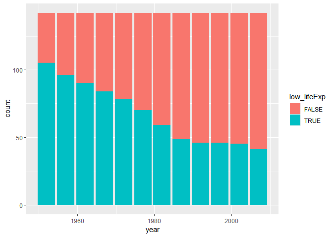

```r
lifeExpCheck %>%
  # year as x axis, and show the portion of low_lifeExp
  ggplot(aes(year, fill = low_lifeExp)) +
  # make it a bar plot
  geom_bar()
```

From the figure, we know that the numbers of countries with low lifeExp become smaller and smller over the years.

## Task #6

**Find countries with interesting stories. Open-ended and, therefore, hard. Promising but unsuccessful attempts are encouraged. This will generate interesting questions to follow up on in class.**

Let’s try to list data in countries in Americas first, and see if we can find something intersting.

```r
countries <- gapminder %>%
  # filter continent as Americas
  filter(continent == "Americas") %>%
  # remove column continent
  select(-continent) %>%
  # group by country and year
  group_by(country, year)

# show previews
head(countries) %>%
  knitr::kable()
```

| country | year | lifeExp | pop | gdpPercap |
| --- | --- | --- | --- | --- |
| Argentina | 1952 | 62.485 | 17876956 | 5911.315 |
| Argentina | 1957 | 64.399 | 19610538 | 6856.856 |
| Argentina | 1962 | 65.142 | 21283783 | 7133.166 |
| Argentina | 1967 | 65.634 | 22934225 | 8052.953 |
| Argentina | 1972 | 67.065 | 24779799 | 9443.039 |
| Argentina | 1977 | 68.481 | 26983828 | 10079.027 |

```r
tail(countries) %>%
  knitr::kable()
```

| country | year | lifeExp | pop | gdpPercap |
| --- | --- | --- | --- | --- |
| Venezuela | 1982 | 68.557 | 15620766 | 11152.410 |
| Venezuela | 1987 | 70.190 | 17910182 | 9883.585 |
| Venezuela | 1992 | 71.150 | 20265563 | 10733.926 |
| Venezuela | 1997 | 72.146 | 22374398 | 10165.495 |
| Venezuela | 2002 | 72.766 | 24287670 | 8605.048 |
| Venezuela | 2007 | 73.747 | 26084662 | 11415.806 |

We try to explore the following things.

### Is there a relationship between lifeExp and pop?

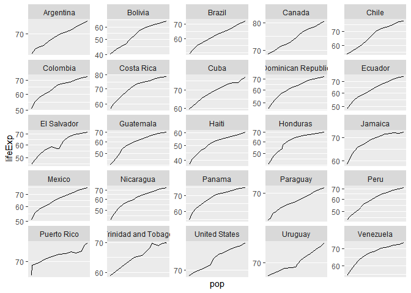

```r
countries %>%
  # pop as x axis and lifeExp as y axis
  ggplot(aes(pop, lifeExp)) +
  # scale y axis by log10
  scale_y_log10() +
  # facetting by country
  facet_wrap(~country, scales = "free") +
  # make a line plot
  geom_line() +
  # make a better x axis
  scale_x_continuous(breaks=NULL)
```

Interestingly, when the population gets larger, the life expectancy also becomes larger!

### What is the overall GDP of each country and how do they change over the years?

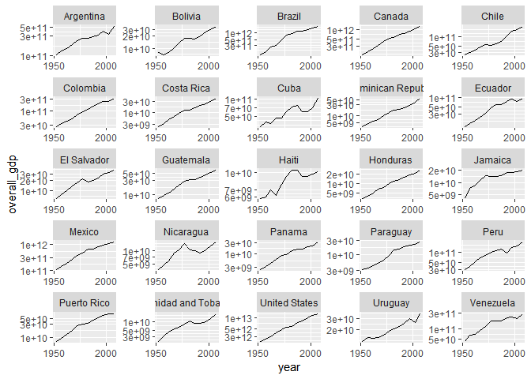

```r
countries_with_overall_gdp <- countries %>%
  # calculate overall GDP
  mutate(
    overall_gdp = pop * gdpPercap
  )

countries_with_overall_gdp %>%
  # year as x axis and overall_gdp as y axis
  ggplot(aes(year, overall_gdp)) +
  # facetting by country
  facet_wrap(~country, scales = "free") +
  # make a line plot
  geom_line() +
  # scale y axis by log10
  scale_y_log10() +
  # make a better x axis
  scale_x_continuous(breaks = scales::pretty_breaks(n = 2))
```

So we can notice some flactuations in these resultant lines. But it is a trend that every country has an increasing overall GDP.

### Does overall GDP affect life expectancy?

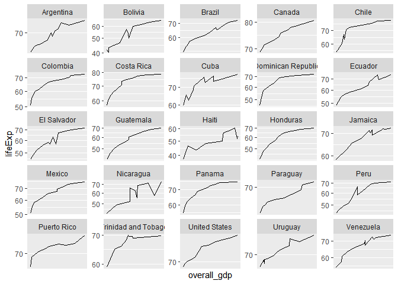

```r
countries_with_overall_gdp %>%
  # overall_gdp as x axis and lifeExp as y axis
  ggplot(aes(overall_gdp, lifeExp)) +
  # facetting by country
  facet_wrap(~country, scales = "free") +
  # scale y axis by log10
  scale_y_log10() +
  # make it a line plot
  geom_line() +
  # make a better x axis
  scale_x_continuous(breaks = NULL)
```

Though we notice some flactuations in these lines, we somehow can conclude that when the overall GDP of a country is high, the lifeExp is also high.

# But I want to do more!

## Layout stretch goal: get table and figure side-by-side.

We directly use code form the third task, but put the table and figure side-by-side.

| year | vanilla_mean | weighted_mean |
| --- | --- | --- |
| 1952 | 49.05762 | 48.94424 |
| 1957 | 51.50740 | 52.12189 |
| 1962 | 53.60925 | 52.32438 |
| 1967 | 55.67829 | 56.98431 |
| 1972 | 57.64739 | 59.51478 |
| 1977 | 59.57016 | 61.23726 |
| 1982 | 61.53320 | 62.88176 |
| 1987 | 63.21261 | 64.41635 |
| 1992 | 64.16034 | 65.64590 |
| 1997 | 65.01468 | 66.84934 |
| 2002 | 65.69492 | 67.83904 |
| 2007 | 67.00742 | 68.91909 |

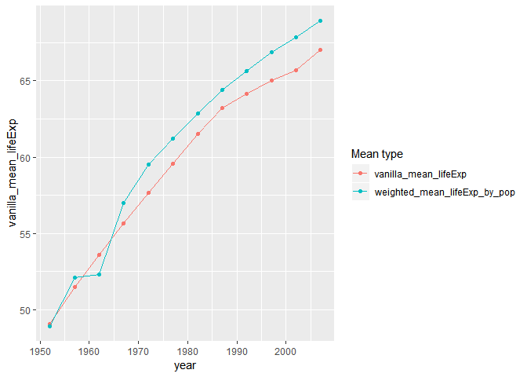

## Table stretch goal: there are some really nice fancy table helper packages.

We show one example (not very fancy) using pander and xtable respectively, assuming these two packages have been already installed.

```r
suppressPackageStartupMessages(library(pander))
suppressPackageStartupMessages(library(xtable))
```

### pander

```r
emphasize.strong.cols(1)
emphasize.italics.cells(which(means >= 60, arr.ind = TRUE))
pander(means)
```

| year | vanilla_mean_lifeExp | weighted_mean_lifeExp_by_pop |
| --- | --- | --- |
| **1952** | 49.06 | 48.94 |
| **1957** | 51.51 | 52.12 |
| **1962** | 53.61 | 52.32 |
| **1967** | 55.68 | 56.98 |
| **1972** | 57.65 | 59.51 |
| **1977** | 59.57 | *61.24* |
| **1982** | *61.53* | *62.88* |
| **1987** | *63.21* | *64.42* |
| **1992** | *64.16* | *65.65* |
| **1997** | *65.01* | *66.85* |
| **2002** | *65.69* | *67.84* |
| **2007** | *67.01* | *68.92* |

### xtable

```r
print(xtable(means), type = "html")
```

|  | year | vanilla_mean_lifeExp | weighted_mean_lifeExp_by_pop |
| --- | --- | --- | --- |
| 1 | 1952 | 49.06 | 48.94 |
| 2 | 1957 | 51.51 | 52.12 |
| 3 | 1962 | 53.61 | 52.32 |
| 4 | 1967 | 55.68 | 56.98 |
| 5 | 1972 | 57.65 | 59.51 |
| 6 | 1977 | 59.57 | 61.24 |
| 7 | 1982 | 61.53 | 62.88 |
| 8 | 1987 | 63.21 | 64.42 |
| 9 | 1992 | 64.16 | 65.65 |
| 10 | 1997 | 65.01 | 66.85 |
| 11 | 2002 | 65.69 | 67.84 |
| 12 | 2007 | 67.01 | 68.92 |

# Notes

- Currently I do not know how to make better labels of x axis in facetting figures. Now I can only suppress all of them for some figures in section “Task #6”.
- I do not like the way to show a table and a figure side-by-side. The reason is, it can be only used in HTML, but on GitHub it does not support direct viewing of HTML.

# References

- [pander: An R Pandoc Writer](http://rapporter.github.io/pander/)
- [The xtable Gallery](https://cran.r-project.org/web/packages/xtable/vignettes/xtableGallery.pdf)